# bellabeat Case Study

Tushar

2025-06-21

## Installed and loaded common packages and libraries

```r
options(repos = c(CRAN = "https://cloud.r-project.org"))
install.packages('tidyverse')
library(tidyverse)
```

## Loaded CSV files from the dataset

### Created a dataframe named ‘daily_activity’, ‘sleep_day’ and read in as the CSV files from the dataset.

```r
daily_activity <- read.csv("C:/Users/s/Desktop/Case Study/Portfolio Projects/bellabeat/Fitabase Data 4.12.16-5.12.16/dailyActivity_merged.csv")
```

```r
sleep_day <- read.csv("C:/Users/s/Desktop/Case Study/Portfolio Projects/bellabeat/Fitabase Data 4.12.16-5.12.16/sleepDay_merged.csv")
```

## Explored a few key tables

```r
head(daily_activity)
```

```
##           Id ActivityDate TotalSteps TotalDistance TrackerDistance
## 1 1503960366    4/12/2016      13162          8.50            8.50
## 2 1503960366    4/13/2016      10735          6.97            6.97
## 3 1503960366    4/14/2016      10460          6.74            6.74
## 4 1503960366    4/15/2016       9762          6.28            6.28
## 5 1503960366    4/16/2016      12669          8.16            8.16
## 6 1503960366    4/17/2016       9705          6.48            6.48
##   LoggedActivitiesDistance VeryActiveDistance ModeratelyActiveDistance
## 1                        0               1.88                     0.55
## 2                        0               1.57                     0.69
## 3                        0               2.44                     0.40
## 4                        0               2.14                     1.26
## 5                        0               2.71                     0.41
## 6                        0               3.19                     0.78
##   LightActiveDistance SedentaryActiveDistance VeryActiveMinutes
## 1                6.06                       0                25
## 2                4.71                       0                21
## 3                3.91                       0                30
## 4                2.83                       0                29
## 5                5.04                       0                36
## 6                2.51                       0                38
##   FairlyActiveMinutes LightlyActiveMinutes SedentaryMinutes Calories
## 1                  13                  328              728     1985
## 2                  19                  217              776     1797
## 3                  11                  181             1218     1776
## 4                  34                  209              726     1745
## 5                  10                  221              773     1863
## 6                  20                  164              539     1728
```

```r
colnames(daily_activity)
```

```
##  [1] "Id"                       "ActivityDate"
##  [3] "TotalSteps"               "TotalDistance"
##  [5] "TrackerDistance"          "LoggedActivitiesDistance"
##  [7] "VeryActiveDistance"       "ModeratelyActiveDistance"
##  [9] "LightActiveDistance"      "SedentaryActiveDistance"
## [11] "VeryActiveMinutes"        "FairlyActiveMinutes"
## [13] "LightlyActiveMinutes"     "SedentaryMinutes"
## [15] "Calories"
```

```r
head(sleep_day)
```

```
##           Id              SleepDay TotalSleepRecords TotalMinutesAsleep
## 1 1503960366 4/12/2016 12:00:00 AM                 1                327
## 2 1503960366 4/13/2016 12:00:00 AM                 2                384
## 3 1503960366 4/15/2016 12:00:00 AM                 1                412
## 4 1503960366 4/16/2016 12:00:00 AM                 2                340
## 5 1503960366 4/17/2016 12:00:00 AM                 1                700
## 6 1503960366 4/19/2016 12:00:00 AM                 1                304
##   TotalTimeInBed
## 1            346
## 2            407
## 3            442
## 4            367
## 5            712
## 6            320
```

```r
colnames(sleep_day)
```

```
## [1] "Id"                 "SleepDay"           "TotalSleepRecords"
## [4] "TotalMinutesAsleep" "TotalTimeInBed"
```

#### Insights: Both datasets have Id which can be used to merge the datasets.

## Summary statistics

### Number of unique participants are there in each dataframe?

```r
n_distinct(daily_activity$Id)
```

```
## [1] 33
```

```r
n_distinct(sleep_day$Id)
```

```
## [1] 24
```

### Number of observations are there in each dataframe?

```r
nrow(daily_activity)
```

```
## [1] 940
```

```r
nrow(sleep_day)
```

```
## [1] 413
```

### Summary statistics about each data frame

### For the daily_activity dataframe:

```r
daily_activity %>%
  select(TotalSteps, TotalDistance, SedentaryMinutes) %>%
  summary()
```

```
##    TotalSteps    TotalDistance    SedentaryMinutes
##  Min.   :    0   Min.   : 0.000   Min.   :   0.0
##  1st Qu.: 3790   1st Qu.: 2.620   1st Qu.: 729.8
##  Median : 7406   Median : 5.245   Median :1057.5
##  Mean   : 7638   Mean   : 5.490   Mean   : 991.2
##  3rd Qu.:10727   3rd Qu.: 7.713   3rd Qu.:1229.5
##  Max.   :36019   Max.   :28.030   Max.   :1440.0
```

### Insights from daily_activity data frame:

#### 1. Half of the users walk fewer than ~7,400 steps per day — below the commonly recommended 10,000 steps.

#### 2. Distance traveled is closely correlated with steps. The average user travels ~5.5 km/day.

#### 3. Users are sedentary for most of the day. This highlights a health concern — long sedentary periods ~1,057 minutes (~17.6 hours)

### For the sleep_day data frame:

```r
sleep_day %>%
  select(TotalSleepRecords,
         TotalMinutesAsleep,
         TotalTimeInBed) %>%
  summary()
```

```
##  TotalSleepRecords TotalMinutesAsleep TotalTimeInBed
##  Min.   :1.000     Min.   : 58.0      Min.   : 61.0
##  1st Qu.:1.000     1st Qu.:361.0      1st Qu.:403.0
##  Median :1.000     Median :433.0      Median :463.0
##  Mean   :1.119     Mean   :419.5      Mean   :458.6
##  3rd Qu.:1.000     3rd Qu.:490.0      3rd Qu.:526.0
##  Max.   :3.000     Max.   :796.0      Max.   :961.0
```

### Insights from sleep_day data frame:

#### 1. Most users have only one sleep session per day, but a few may nap or track segmented sleep (up to 3 sessions).

#### 2. Most users get around 419.5 minutes (~7 hours) of sleep, which aligns with health guidelines (but some sleep less than 1 hour — possible outliers).

#### 3. There’s a gap between time in bed and actual sleep, suggesting some time spent awake (e.g., ~30–40 min).

## Plotting a few explorations

### Relationship between steps taken in a day and sedentary minutes?

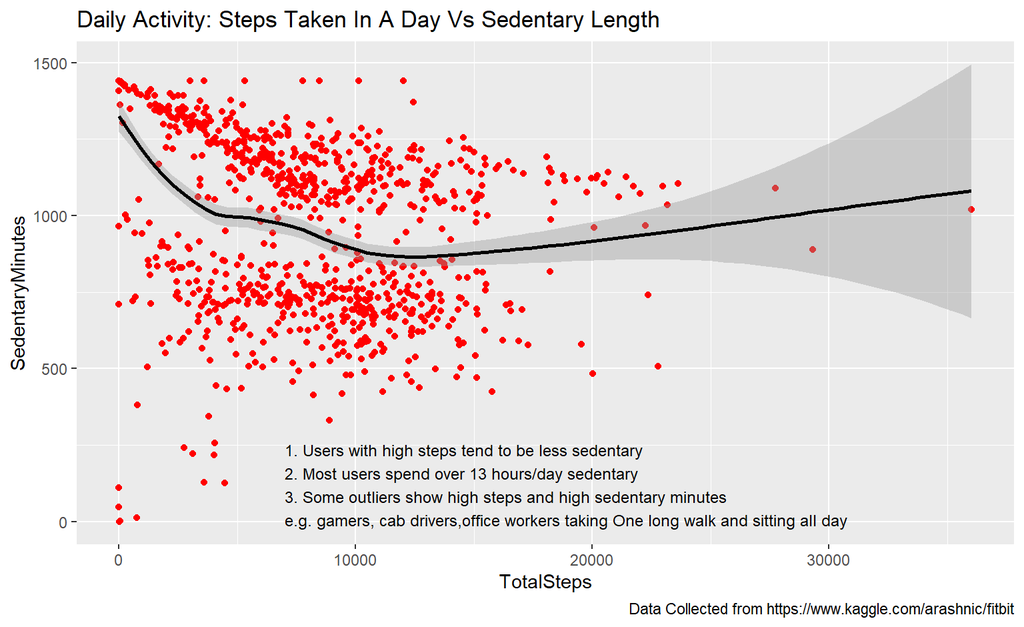

```r
ggplot(data=daily_activity, aes(x=TotalSteps, y=SedentaryMinutes)) +
  geom_point(colour = 'red') +
  geom_smooth(method = 'loess', formula = y~x, color='black') +
  labs(title = "Daily Activity: Steps Taken In A Day Vs Sedentary Length  ",
       caption ="Data Collected from https://www.kaggle.com/arashnic/fitbit") +
  annotate("text", x=7000, y=120, hjust=0,size=3.2,
           label =paste0("1. Users with high steps tend to be less sedentary\n2. Most users spend over 13 hours/day sedentary\n3. Some outliers show high steps and high sedentary minutes\ne.g. gamers, cab drivers,office workers taking One long walk and sitting all day"))
```

### Insights:

#### 1. Inverse Trend: More steps generally mean fewer sedentary minutes, especially up to ~12,000 steps.

#### 2. Sedentary Lifestyle: Most users remain inactive for over 13 hours/day.

#### 3. Outliers: Some users show high steps and high sedentary time—likely due to long walks followed by prolonged sitting (e.g., gamers, drivers, office workers).

### Relationship between minutes asleep and time in bed?

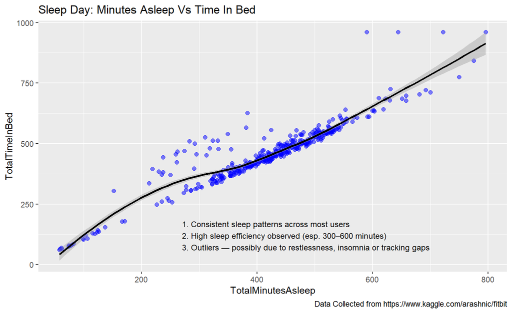

```r
ggplot(data = sleep_day, aes(x = TotalMinutesAsleep, y = TotalTimeInBed)) +
  geom_point(color = "blue", alpha = 0.5, size =2) +
  geom_smooth(method = 'loess', formula = y ~ x, color = "black") +
  labs(
    title = "Sleep Day: Minutes Asleep Vs Time In Bed",
    caption = "Data Collected from https://www.kaggle.com/arashnic/fitbit"
  ) +
  annotate(
    "text", x = 270, y = 120, hjust = 0, size = 3.2,
    label = paste(
      "1. Consistent sleep patterns across most users",
      "2. High sleep efficiency observed (esp. 300–600 minutes)",
      "3. Outliers — possibly due to restlessness, insomnia or tracking gaps", sep = "\n"
    )
  )
```

### Insights:

#### 1. Strong Positive Correlation - More time in bed generally results in more sleep.

#### 2. High Sleep Efficiency - Most users sleep efficiently, especially in the 300–600 minute range.

#### 3. Visible Outliers - Some users spend a long time in bed but sleep less — possibly due to restlessness, insomnia, or device tracking gaps.

## Merging these two datasets together

```r
combined_data <- merge(sleep_day, daily_activity, by="Id", all = TRUE)
```

### How many participants are in the combined data set and what attributes can be explored ?

```r
n_distinct(combined_data$Id)
```

```
## [1] 33
```

```r
colnames(combined_data)
```

```
##  [1] "Id"                       "SleepDay"
##  [3] "TotalSleepRecords"        "TotalMinutesAsleep"
##  [5] "TotalTimeInBed"           "ActivityDate"
##  [7] "TotalSteps"               "TotalDistance"
##  [9] "TrackerDistance"          "LoggedActivitiesDistance"
## [11] "VeryActiveDistance"       "ModeratelyActiveDistance"
## [13] "LightActiveDistance"      "SedentaryActiveDistance"
## [15] "VeryActiveMinutes"        "FairlyActiveMinutes"
## [17] "LightlyActiveMinutes"     "SedentaryMinutes"
## [19] "Calories"
```

### Do the participants who sleep more take more steps or fewer steps per day? Is there a relationship at all?

```r
library(dplyr)
clean_combined_data <- combined_data %>%
  filter(
    !is.na(TotalMinutesAsleep),
    !is.na(TotalTimeInBed),
    is.finite(TotalMinutesAsleep),
    is.finite(TotalTimeInBed)
  )
```

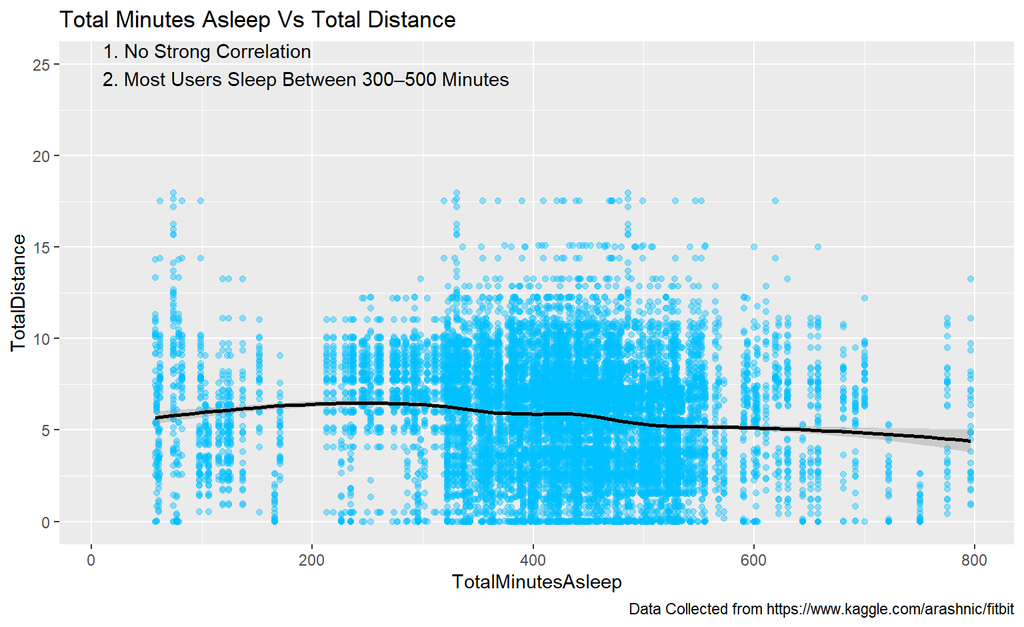

```r
ggplot(data = clean_combined_data, aes(x = TotalMinutesAsleep, y = TotalDistance)) +
  geom_point(color = "deepskyblue", alpha = 0.4) +
  geom_smooth(method = "loess", color = "black", formula = y~x) +
  labs(title = "Total Minutes Asleep Vs Total Distance",
    caption = "Data Collected from https://www.kaggle.com/arashnic/fitbit") +
  annotate("text", x = 10, y = 25, hjust = 0, label =
           "1. No Strong Correlation\n2. Most Users Sleep Between 300–500 Minutes")
```